# Bayesian Deep Learning with Edward (and a trick using Dropout)

7 May 2017

## Roadmap

- Bayesian Deep Learning
- Probabilistic Programming with Edward
- Dropout as a Bayesian Approximation in Deep Neural Networks
- Experiments

## Bayesian Deep Learning

## Deep Learning

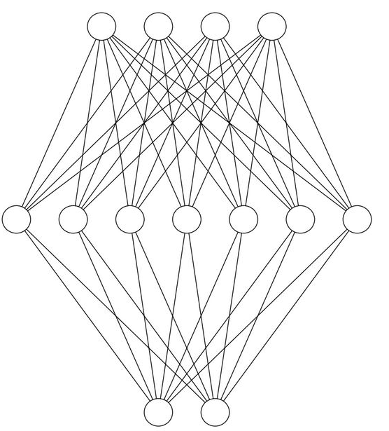

- State of the art in a wide range of applications: computer vision, speech recognition, natural language processing etc.
- Neural network architectures: Feedforward, Recurrent, Convolutional…
- Deeper neural networks and massive datasets: stochastic gradient descent, backpropagation, dropout
- Deep Reinforcement Learning: represent Q-value functions, which estimate quality of an agent's next action, as deep neural networks

## Drawbacks of Standard Deep Learning

- Neural networks compute point estimates
- Neural networks make overly confident decisions about the correct class, prediction or action
- Neural networks are prone to overfitting
- Neural networks have many hyperparameters that may require specific tuning

## Probabilistic Machine Learning

**Aim**: Use probability theory to express all forms of uncertainty

- Uncertainty estimates needed in forecasting, decision making, learning from limited and noisy data
- AI Safety: medicine, engineering, finance, etc.
- The probabilistic approach provides a way to **reason about uncertainty** and **learn from data**

## Bayesian Neural Networks

A Bayesian neural network is a neural network with a prior distribution on the weights

- Accounts for uncertainty in weights
- Propagates this into uncertainty about predictions
- More robust against overfitting: randomly sampling over network weights as a cheap form of model averaging
- Can infer network hyperparameters by marginalising them out of the posterior distribution

## Bayesian Neural Networks

- Data \(\mathcal{D} = \{\mathbf{X}_i, y_i \}_{i=1}^{N}\) for input data point \(\mathbf{X}_i \in \mathbb{R}^d\) and output \(y_i \in \mathbb{R}\).
- Parameters: network weights \(\mathbf{w}\) and biases \(b\).
- For Bayesian neural networks **normal priors** are often used: \(p(\mathbf{w)} = \mathcal{N}(\mu, \Sigma)\)

## Bayesian Neural Networks

- Posterior: \(p(\mathbf{w} \vert \mathbf{X},y) = \frac{\displaystyle{ p(y \vert \mathbf{X}, \mathbf{w} )p(\mathbf{w}) }} { \displaystyle{p(y\vert \mathbf{X})} }\)
- Predictive distribution of output \(y^*\) given a new input \(\mathbf{x}^*\): \[p(y^* \vert \mathbf{x}^*, \mathbf{X}, y) = \int p(y^* \vert \mathbf{x}^*, \mathbf{w})p(\mathbf{w} \vert \mathbf{X}, y) d\mathbf{w}\]

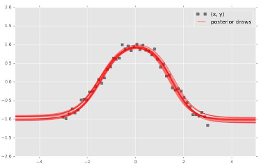

http://edwardlib.org/

## Bayesian Neural Networks

- **But exact inference is intractable!**
- Need to **approximate** the weight posterior \(p(\mathbf{w} \vert \mathbf{X},y)\)

## History of Bayesian Neural Networks

### Approximate Inference in Bayesian Neural Networks

- Laplace Approximation - David MacKay (1992)
- Minimal Description Length - Hinton & Van Kamp (1993)
- Hamiltonian Monte Carlo - Radford Neal (1995)
- Ensemble Learning - Barber & Bishop (1998)
- Methods not **scalable** for modern applications and massive data sets

See Zoubin Ghahramani's NIPS 2016 keynote address on 'History of Bayesian Neural Networks': https://www.youtube.com/watch?v=FD8l2vPU5FY

## Modern Revival: Bayesian Deep Learning

[figure not shown]

**NIPS 2016:** bayesiandeeplearning.org

## Modern Revival: Bayesian Deep Learning

- *Practical Variational Inference for Neural Networks*, A Graves, NIPS 2011.
- *Auto-Encoding Variational Bayes*, D P. Kingma, M Welling, CoRR abs/1312.6114, 2013.
- *Stochastic Backpropagation and Approximate Inference in Deep Generative Models*, D Rezende, S Mohamed, and D Wierstra, ICML 2014.
- *Weight uncertainty in neural networks*, C Blundell, J Cornebise, K Kavukcuoglu, and D Wierstra, ICML 2015.
- *Probabilistic backpropagation for scalable learning of Bayesian neural networks*, J M Hernandez-Lobato, R P Adams, ICML 2015
- *Dropout as a Bayesian Approximation: Representing Model Uncertainty in Deep Learning*, Y Gal, Z Ghahramani, ICML 2016

See Yarin Gal's PhD thesis: *Uncertainty in Deep Learning*, University of Cambridge (2016)

## Probabilistic Programming with Edward

## Probabilistic Programming

### Overview

- Represent probabilistic models as **programs** that generate **samples**
- Automate inference of **unobserved** variables in the model **conditioned** on observed progam output
- **Probabilistic Programming Languages** (PPLs): Church, Venture, Anglican, Figaro, WebPPL, Stan, PyMC3, Edward etc.
- Many PPLs treat inference as a **black box** abstracted away from model
- Separation of model and inference: harder to represent some recent advances, e.g. Generative Adversarial Networks
- **Expressivity versus Scalability trade-off**

## Probabilistic Programming

*"All sufficiently complex PPLs eventually reimplement probabilistic LISP."*

Daniel Roy, University of Toronto

## Edward

### edwardlib.org

- Edward is a thin platform over TensorFlow
- Edward = TensorFlow

## Edward

### edwardlib.org

- Edward is a thin platform over TensorFlow
- Edward = TensorFlow + Random Variables

## Edward

### edwardlib.org

- Edward is a thin platform over TensorFlow
- Edward = TensorFlow + Random Variables + Inference Algorithms

## A brief diversion into TensorFlow

- TensorFlow is a **computational graph** framework
- Graph **nodes** are **operations**: arithmetic, looping, indexing etc.
- Graph **edges** are **tensors** representing data communicated between nodes
- Do everything in the computational graph: scale, distribute, GPU etc.

*TensorFlow: Large-Scale Machine Learning on Heterogeneous Distributed Systems*, White Paper, M Abadi et al (2015)

## Edward

### Models

Edward's **Random Variables** are **class objects** with methods: `log_prob()`, `samples()`, summary statistics etc.

#### How to embed **random variables** into the computational graph?

- A random variable \(\mathbf{x}\) wraps a TensorFlow tensor \(\mathbf{x^*}\), where \(\mathbf{x^*} \sim p(\mathbf{x})\) is a **sample** from the random variable object
- **Use this to define probabilistic models**

## Edward

### Inference

- Edward's `Inference` algorithms define a TensorFlow computational graph
- Inference can be written as a collection of separate inference programs
- Leverage TensorFlow **optimisers**, e.g. ADAM for Variational Inference; gradient structure for Hamiltonian Monte Carlo

## Edward

### Expressivity and Scalability

- Allows composition of Models *and* of Inference methods for greater **expressivity**
- Allows data subsampling for greater **scalability**

## Edward Philosophy

George Edward Pelham Box's loop as a Design Principle

```
1.    Build a model of the science
2.    Infer the model given data
3.    Criticize the model given data (Posterior Predictive Checks)
```

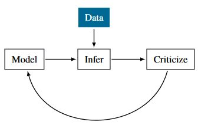

Dustin Tran, Alp Kucukelbir, Adji B. Dieng, Maja Rudolph, Dawen Liang, and David M. Blei. 2016. *Edward: A library for probabilistic modeling, inference, and criticism.* arXiv preprint arXiv:1610.09787.

Dustin Tran, Matthew D. Hoffman, Rif A. Saurous, Eugene Brevdo, Kevin Murphy, and David M. Blei. 2017. *Deep Probabilistic Programming.* International Conference on Learning Representations.

## 2-Layer Neural Network in TensorFlow

```python
import tensorflow as tf

def neural_network(x, W_0, W_1, W_2, b_0, b_1, b2):
  h = tf.tanh(tf.matmul(x, W_0) + b_0)
  h = tf.tanh(tf.matmul(h, W_1) + b_1)
  h = tf.matmul(h, W_2) + b_2
  return tf.reshape(h, [-1])
```

## 2-Layer Neural Network in TensorFlow + Edward

```python
import tensorflow as tf

def neural_network(x, W_0, W_1, W_2, b_0, b_1, b2):
  h = tf.tanh(tf.matmul(x, W_0) + b_0)
  h = tf.tanh(tf.matmul(h, W_1) + b_1)
  h = tf.matmul(h, W_2) + b_2
  return tf.reshape(h, [-1])
```

```python
from edward.models import Normal

W_0 = Normal(loc=tf.zeros([D, n_hidden]), scale=tf.ones([D, n_hidden]))
W_1 = Normal(loc=tf.zeros([n_hidden, n_hidden]), scale=tf.ones([n_hidden, n_hidden]))
W_2 = Normal(loc=tf.zeros([n_hidden, 1]), scale=tf.ones([n_hidden, 1]))
b_0 = Normal(loc=tf.zeros(n_hidden), scale=tf.ones(n_hidden))
b_1 = Normal(loc=tf.zeros(n_hidden), scale=tf.ones(n_hidden))
b_2 = Normal(loc=tf.zeros(1), scale=tf.ones(1))
```

## Inference in Edward

- Let `x` and `y` be observed random variables, and `x_train` and `y_train` be atually observed data
- Let `w_0`, `w_1`, `b_0` and `b_1` be latent variables in model
- Let `qw_0`, `qw_1`, `qb_0` and `qb_1` be random variables defined to approximate the posterior
- Bind model latent random variables to posterior random variables: `{w_0: qw_0, b_0: qb_0, w_1: qw_1, b_1: qb_1}`
- Bind observed random variable to the training data: `{x: x_train, y: y_train}`

## Inference in Edward

- Select some inference algorithm (e.g. Variational Inference, Monte Carlo)

```python
inference = ed.Inference(latent_vars={w_0: qw_0, b_0: qb_0,
                                      w_1: qw_1, b_1: qb_1},
                         data={x: x_train, y: y_train})
```

- **This abstraction can represent a broad class of inference algorithms**

## Variational Inference

### Recasting Bayesian inference as optimisation

- Approximate the posterior \(p(\mathbf{w} \vert \mathbf{X, Y})\) with a simpler distribution from a variational family of distributions \(q_{\theta}(\mathbf{w})\) parameterised by \(\theta\)
- **Minimise** the Kullback-Leibler (KL) divergence between **approximate** posterior \(q_{\theta}(\mathbf{w})\) and the **actual** posterior \(p(\mathbf{w} \vert \mathbf{X, Y})\) w.r.t. \(\theta\)
- **Mean Field** approximation: factorise the approximating posterior \(q_{\theta}(\mathbf{w})\) into **independent** distributions for each weight layer
- But minimising KL divergence is **hard**! (because of the *evidence* term \(\text{log } p(\mathbf{Y}| \mathbf{X})\)!)
- Minimising the KL divergence = **maximising** the **Evidence Lower BOund (ELBO)** w.r.t. \(\theta\)

## Variational Inference

### Evidence Lower Bound

\[\text{ELBO} = \underbrace{\mathbb{E}_{q_{\theta}}[\log p(\mathbf{x} \vert \mathbf{z})]}_\text{Expected Log Likelihood} - \underbrace{ \text{KL}( q_{\theta}(\mathbf{z}) \| p(\mathbf{z})] }_\text{Prior KL}\]

- **Expected Log Likelihood**: measures how well samples from approximate posterior \(q_{\theta}(\mathbf{z})\) explain data \(\mathbf{x}\) *(reconstruction cost)*
- **Prior KL**: ensures explanation of doesn't deviate too far from our prior beliefs *(penalises complexity)*

## Variational Inference

### Estimating the gradient

- **Optimise** the ELBO : need unbiased estimator of its **gradient**
- **Gradient of ELBO**: estimate using Monte Carlo sampling from the variational posterior \(q_{\theta}(\mathbf{w})\) *(score functions, reparameterisation trick)*
- No assumptions made about underlying model: 'black box' approach for **scalable** learning of complex models
- Problem: high variance of Monte Carlo estimator of the gradient!

## Black Box Variational Inference with Edward

- Edward minimises the objective by automatically selecting from a variety of **black box** inference techniques
- Edward applies variance reduction to the Monte Carlo gradient estimator
- Edward computes the Prior KL automatically when \(p(\mathbf{z})\) and \(q_{\theta}(\mathbf{z})\) are Normal
- Allows Black Box Variational Inference to be implemented in a wide variety of models

## Dropout as a Bayesian Approximation

## Dropout

- Deep neural networks: many parameters; very prone to overfitting; require large data sets
- **Dropout** is an empirical technique used to avoid overfitting in neural networks
- Dropout multiplies hidden activations by Bernoulli distributed random variables which take the value 1 with probability \(p\) and 0 otherwise
- Randomly "drop out" hidden units and their connections during training time to prevents hidden units from co-adapting too much
- Often yields significant improvements over other regularisation methods

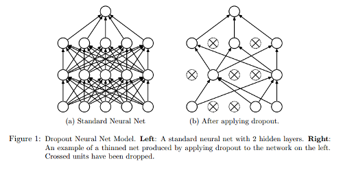

- *Dropout: A Simple Way to Prevent Neural Networks from Overfitting* - Srivastava, Hinton, Krizhevsky, Sutskever, Salakhutdinov - J. Machine Learning Research (2014)

## Dropout Objective

\[\mathcal{L}_{\text{dropout}} = \underbrace{ \frac{1}{N} \sum_{i=1}^{N} E(\mathbf{y}_{i}, \mathbf{\hat{y}}_{i})}_\text{Loss function} + \underbrace{ \lambda \sum_{i=1}^{L} (\|\mathbf{W}_{i} \|^2 + \| \mathbf{b}_{i} \|^2 )}_{L_2 \text{ regularisation with weight decay} \lambda}\]

**How is Dropout in non-probabilistic neural nets connected to variational inference in Bayesian neural nets?**

- **Gal & Ghahramani**: **Reparameterise** the approximate variational distribution \(q_{\theta}(\mathbf{w})\) to be non-Gaussian (Bernouilli)
- **Factorise** the distribution for each neural network weight **row** in each weight matrix
- Now compare dropout objective to ELBO objective using this **reparameterised** \(q_{\theta}(\mathbf{w})\)

## Dropout as a Bayesian Approximation

- **Gal & Ghahramani**: **Approximate ELBO** and **Dropout NN** objectives are **identical** (given this choice of approximating **reparameterised** posterior \(q_{\theta}(\mathbf{w})\) and **normal priors** over network weights)
- Optimising *any* neural network with dropout is equivalent to a form of approximate Bayesian inference
- A network trained with dropout already *is* a Bayesian Neural Network!

## Dropout as a Bayesian Approximation

### Practical Application

- Gal and Ghahramani's method (**MC Dropout**) requires applying dropout at **every** weight layer at **test time**
- For input \(\mathbf{x}^{*}\) the predictive distribution for output \(\mathbf{y}^*\) is \[q(\mathbf{y}^{*}\vert \mathbf{x}^{*}) = \int p(\mathbf{y}^{*}\vert \mathbf{x}^{*}, \mathbf{w}) q(\mathbf{w} \vert \mathbf{X, Y} )\]
- **MC Dropout** averages over \(T\) forward passes through the network at test time
- To estimate **predictive mean** and **predictive uncertainty**:
- Simply collect the results of stochastic forward passes through an existing Neural Network already trained with Dropout!

## MC Dropout Experiments

Highly competitive results for

- **Convolutional Neural Networks:** *Bayesian Convolutional Neural Networks with Bernoulli Approximate Variational Inference*, Y Gal, Z Ghahramani, ICLR 2016
- **Recurrent Neural Networks:** *A Theoretically Grounded Application of Dropout in Recurrent Neural Networks*, Y Gal, Z Ghahramani, NIPS 2016
- **Reinforcement Learning:** *Improving PILCO with Bayesian Neural Network Dynamics Models*, Y Gal, R McAllister, C Rasmussen, ICML 2016

http://mlg.eng.cam.ac.uk/yarin/publications.html

## Experiments

## MC Dropout versus Black Box Variational Inference

- **Feedforward Neural Networks** with 2 hidden layers and 50 units per layer
- Same benchmark data sets and architecture as Hernandez-Lobato & Adams (2015) and Gal & Ghaharmani (2016)

*Probabilistic Backpropagation for Scalable Learning of Bayesian Neural Networks*, J M Hernandez-Lobato, R P Adams, ICML 2015

*Dropout as a Bayesian Approximation: Representing Model Uncertainty in Deep Learning*, Y Gal, Z Ghahramani, ICML 2016

## MC Dropout

- Yarin Gal's MC Dropout: https://github.com/yaringal/DropoutUncertaintyExps
- Harvard Intelligent Probabilistic Systems Group: https://github.com/HIPS/Probabilistic-Backpropagation (Hernandez-Lobato & Adams):
- Uses Keras (Chollet, 2015) and Theano (Bergstra et al, 2010)

## Results

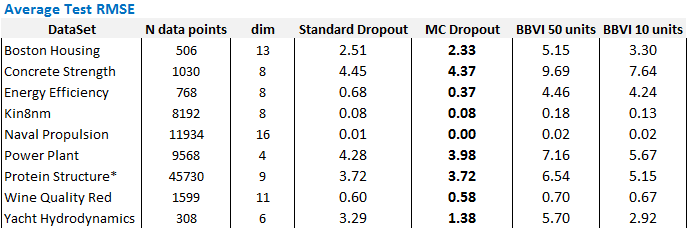

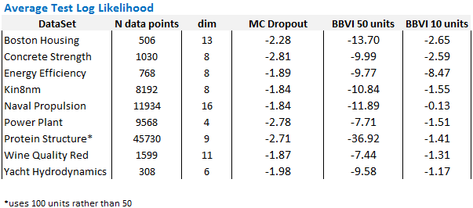

## Model-Specific versus Black Box

- Black Box Variational Inference: aims for maximum **flexibility** and **model independence**
- Edward uses **mean field** VI: factorises the approximating posterior \(q(\mathbf{w})\) into **independent** distributions for **each** latent variable: \(\prod_{i=i}^{l}q_i(w_i)\):

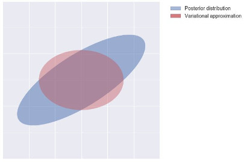

https://github.com/springcoil/advanced_pymc3

- **Mean Field** VI cannot capture posterior **dependencies** between network weight layers

## Model-Specific versus Black Box

- **MC Dropout**: joint distribution over each layer's weights is multimodal (mixtures of delta peaks)
- For Bayesian Neural Networks, including correlations between layers improves results: see Louizos & Welling (2016)

## Current Research in Variational Inference

- **Better variational posterior approximations**: Normalising Flows, Hierarchical Variational Models etc.

  [Rezende & Mohamed 2015, Ranganath, Tran & Blei 2016, Louizos & Welling 2016]
- **Lower variance ELBO estimators**:

  [G Roeder et al 2017, C Naesseth et al 2017, J Sakaya et al 2017]

## Thanks for listening!

**We are hiring!**

## References

- *Structured and Efficient Variational Deep Learning with Matrix Posteriors* - C Louizos & M Welling. arXiv:1603.04733 (2016)
- *Multiplicative Normalizing Flows for Variational Bayesian Neural Networks* - C Louizos & M Welling. arXiv:1703.01961 (2017)
- *Hierarchical variational models*, Ranganath, D. Tran, and D. M. Blei. ICML 2016.
- *Black box Variational Inference*. R. Ranganath, S. Gerrish, and D. M. Blei. Artificial Intelligence and Statistics, 2014.
- *Variational inference with normalizing flows*, D J Rezende, S Mohamed, ICML 2015.
- *Reparameterization Gradients through Acceptance-Rejection Sampling Algorithms* - C Naesseth, F Ruiz, S Linderman, D M Blei (2017)
- *Importance Sampled Stochastic Optimization for Variational Inference*, J Sakaya, A Klami, arXiv:1704.05786 (2017)
- *Sticking the Landing: An Asymptotically Zero-Variance Gradient Estimator for Variational Inference*, G Roeder, Y Wu, D Duvenaud (2017)
- *Edward: A library for probabilistic modeling, inference, and criticism.*, D Tran, A Kucukelbir, A B Dieng, M Rudolph, D Liang, and D M Blei. arXiv:1610.09787.
- *Deep Probabilistic Programming.* D Tran, M Hoffman, R A Saurous, E Brevdo, K Murphy, and D M Blei, ICLR 2017
- *Practical Variational Inference for Neural Networks*, A Graves, NIPS 2011.
- *Auto-Encoding Variational Bayes*, D P. Kingma, M Welling, CoRR abs/1312.6114, 2013.
- *Stochastic Backpropagation and Approximate Inference in Deep Generative Models*, D J Rezende, S Mohamed, and D Wierstra, ICML 2014.
- *Weight uncertainty in neural networks*, C Blundell, J Cornebise, K Kavukcuoglu, and D Wierstra, ICML 2015.
- *Probabilistic backpropagation for scalable learning of Bayesian neural networks*, J M Hernandez-Lobato, R P Adams, ICML 2015
- *Dropout as a Bayesian Approximation: Representing Model Uncertainty in Deep Learning*, Y Gal, Z Ghahramani, ICML 2016

## References

- *Uncertainty in Deep Learning*, Y Gal, PhD Thesis, University of Cambridge (2016)
- *Bayesian Convolutional Neural Networks with Bernoulli Approximate Variational Inference*, Y Gal, Z Ghahramani, ICLR 2016
- *A Theoretically Grounded Application of Dropout in Recurrent Neural Networks*, Y Gal, Z Ghahramani, NIPS 2016
- *Improving PILCO with Bayesian Neural Network Dynamics Models*, Y Gal, R McAllister, C Rasmussen, ICML 2016